# Biodiversity Analysis

Gurpreet Kaur

2024-04-30

# Setting the Environment

## Set the seed

```r
set.seed(238427)
```

## Load Libraries

```r
pacman::p_load(tidyverse, devtools, patchwork, iNEXT, phyloseq,
               install = FALSE)
```

## Load in Data

```r
load("data/02_PreProcessing/raw_preprocessed_physeq.RData")
raw_preprocessed_physeq
```

```
## phyloseq-class experiment-level object
## otu_table()   OTU Table:         [ 6484 taxa and 59 samples ]
## sample_data() Sample Data:       [ 59 samples by 44 sample variables ]
## tax_table()   Taxonomy Table:    [ 6484 taxa by 9 taxonomic ranks ]
```

```r
# Intiution Check
min(sample_sums(raw_preprocessed_physeq))
```

```
## [1] 17469
```

```r
# Make metadata dataframe
metadata_df <-
  raw_preprocessed_physeq %>%
  sample_data() %>%
  data.frame()

head(metadata_df)
```

```
##                   names      altitude Assay.Type AvgSpotLen    Bases
## SRR11364336 SRR11364336 not collected   AMPLICON        602 29559404
## SRR11364337 SRR11364337 not collected   AMPLICON        602 36089298
## SRR11364338 SRR11364338 not collected   AMPLICON        602 30865744
## SRR11364339 SRR11364339 not collected   AMPLICON        602 32678366
## SRR11364340 SRR11364340 not collected   AMPLICON        602 25259920
## SRR11364341 SRR11364341 not collected   AMPLICON        602 38462382
##              BioProject    BioSample              BioSampleModel    Bytes
## SRR11364336 PRJNA613763 SAMN14419188 Metagenome or environmental 17409112
## SRR11364337 PRJNA613763 SAMN14419187 Metagenome or environmental 21355996
## SRR11364338 PRJNA613763 SAMN14419186 Metagenome or environmental 18282890
## SRR11364339 PRJNA613763 SAMN14419185 Metagenome or environmental 19299644
## SRR11364340 PRJNA613763 SAMN14419238 Metagenome or environmental 14614781
## SRR11364341 PRJNA613763 SAMN14419237 Metagenome or environmental 21996159
##                               Center.Name Collection_Date Consent
## SRR11364336 HENAN AGRICULTURAL UNIVERSITY            2019  public
## SRR11364337 HENAN AGRICULTURAL UNIVERSITY            2019  public
## SRR11364338 HENAN AGRICULTURAL UNIVERSITY            2019  public
## SRR11364339 HENAN AGRICULTURAL UNIVERSITY            2019  public
## SRR11364340 HENAN AGRICULTURAL UNIVERSITY            2014  public
## SRR11364341 HENAN AGRICULTURAL UNIVERSITY            2014  public
##             DATASTORE.filetype DATASTORE.provider
## SRR11364336   sra,run.zq,fastq         ncbi,gs,s3
## SRR11364337   sra,fastq,run.zq         s3,ncbi,gs
## SRR11364338   fastq,sra,run.zq         s3,ncbi,gs
## SRR11364339   fastq,run.zq,sra         gs,s3,ncbi
## SRR11364340   run.zq,sra,fastq         s3,ncbi,gs
## SRR11364341   fastq,run.zq,sra         ncbi,gs,s3
##                           DATASTORE.region Experiment geo_loc_name_country
## SRR11364336 gs.US,ncbi.public,s3.us-east-1 SRX7965784                China
## SRR11364337 gs.US,s3.us-east-1,ncbi.public SRX7965783                China
## SRR11364338 gs.US,ncbi.public,s3.us-east-1 SRX7965782                China
## SRR11364339 ncbi.public,gs.US,s3.us-east-1 SRX7965781                China
## SRR11364340 s3.us-east-1,gs.US,ncbi.public SRX7965780                China
## SRR11364341 s3.us-east-1,ncbi.public,gs.US SRX7965779                China
##             geo_loc_name_country_continent                   geo_loc_name Id
## SRR11364336                           Asia China:Xuchang\\,Henan Province 10
## SRR11364337                           Asia China:Xuchang\\,Henan Province  9
## SRR11364338                           Asia China:Xuchang\\,Henan Province  8
## SRR11364339                           Asia China:Xuchang\\,Henan Province  7
```

[output cut: 22 more lines]

```
## SRR11364341 ILLUMINA 2020-03-31T00:00:00Z 2020-03-22T02:53:00Z       1
##             Sample.Name treatment year SRA.Study        strain input filtered
## SRR11364336    sample10      N180   10 SRP253595 not collected 49102    49102
## SRR11364337    sample09      N180   10 SRP253595 not collected 59949    59949
## SRR11364338    sample08      N120   10 SRP253595 not collected 51272    51272
## SRR11364339    sample07      N120   10 SRP253595 not collected 54283    54283
## SRR11364340    sample60      N360    5 SRP253595 not collected 41960    41960
## SRR11364341    sample59      N360    5 SRP253595 not collected 63891    63891
##             denoisedF denoisedR merged nochim perc_reads_retained
## SRR11364336     41856     42877  23454  23135            47.11621
## SRR11364337     52876     53369  31060  30696            51.20352
## SRR11364338     43791     44513  24011  23697            46.21821
## SRR11364339     46173     47553  25753  25578            47.11972
## SRR11364340     35805     36067  20194  19849            47.30458
## SRR11364341     54406     56399  31614  31033            48.57179
```

```r
# Setting colors for treatments to match with dataset from the paper
treatment_colors <- c(
  "N0" = "brown3",
  "N120" = "dodgerblue4",
  "N180" = "darkolivegreen4",
  "N240" = "gold",
  "N360" = "deeppink4")
```

# Goals

1. Calculate the Hill Diversity of the samples.
2. Evaluate the rarefaction curves.
3. Evaluate the Diversity values.
4. Makes notes of specific samples and their seq depth.

# Diversity Calculations with iNEXT

```r
# prepare input data
iNEXT_input_df <-
  raw_preprocessed_physeq %>%
  otu_table() %>%
  data.frame()

# Quick check

dim(iNEXT_input_df)
```

```
## [1] 6484   59
```

```r
# Run iNEXT: Calculate the Hill Numbers
# Note that: Species in ROWS, Samples in COLUMNS
# Remember to set the seed!
#iNEXT_data <- iNEXT(iNEXT_input_df,
                   # q = c(0,1,2), datatype = "abundance")

# Save the file
#save(iNEXT_data, file = "data/04_Biodiversity/iNEXT_data.RData")
```

# Evaluate the Diversity!

```r
load("data/04_Biodiversity/iNEXT_data.RData")
str(iNEXT_data)
```

```
## List of 3
##  $ DataInfo:'data.frame':    60 obs. of  14 variables:
##   ..$ Assemblage: chr [1:60] "SRR11364336" "SRR11364337" "SRR11364338" "SRR11364339" ...
##   ..$ n         : num [1:60] 23118 30680 23695 25578 19846 ...
##   ..$ S.obs     : num [1:60] 742 920 791 835 757 ...
##   ..$ SC        : num [1:60] 1 1 1 1 1 ...
##   ..$ f1        : num [1:60] 5 15 6 9 3 15 9 15 13 12 ...
##   ..$ f2        : num [1:60] 6 9 9 12 12 16 19 11 7 17 ...
##   ..$ f3        : num [1:60] 13 12 14 12 20 16 21 15 16 15 ...
##   ..$ f4        : num [1:60] 11 12 13 6 18 15 20 16 8 25 ...
##   ..$ f5        : num [1:60] 14 12 20 22 12 28 27 29 19 20 ...
##   ..$ f6        : num [1:60] 14 19 14 14 22 34 24 22 20 40 ...
##   ..$ f7        : num [1:60] 20 20 21 21 15 32 30 30 18 29 ...
##   ..$ f8        : num [1:60] 18 16 19 15 27 26 27 25 31 25 ...
##   ..$ f9        : num [1:60] 19 26 19 34 30 17 22 20 21 33 ...
##   ..$ f10       : num [1:60] 17 30 31 15 35 32 47 19 18 33 ...
##  $ iNextEst:List of 2
##   ..$ size_based    :'data.frame':   7200 obs. of  10 variables:
##   .. ..$ Assemblage: chr [1:7200] "SRR11364336" "SRR11364336" "SRR11364336" "SRR11364336" ...
##   .. ..$ m         : num [1:7200] 1 1285 2569 3853 5137 ...
##   .. ..$ Method    : chr [1:7200] "Rarefaction" "Rarefaction" "Rarefaction" "Rarefaction" ...
##   .. ..$ Order.q   : num [1:7200] 0 0 0 0 0 0 0 0 0 0 ...
##   .. ..$ qD        : num [1:7200] 1 512 632 679 702 ...
##   .. ..$ qD.LCL    : num [1:7200] 1 509 628 675 699 ...
##   .. ..$ qD.UCL    : num [1:7200] 1 515 635 683 706 ...
##   .. ..$ SC        : num [1:7200] 0.0025 0.8439 0.9461 0.9753 0.9868 ...
##   .. ..$ SC.LCL    : num [1:7200] 0.00244 0.84235 0.94509 0.97453 0.98625 ...
##   .. ..$ SC.UCL    : num [1:7200] 0.00255 0.84552 0.94714 0.976 0.98727 ...
##   ..$ coverage_based:'data.frame':   7200 obs. of  8 variables:
##   .. ..$ Assemblage: chr [1:7200] "SRR11364336" "SRR11364336" "SRR11364336" "SRR11364336" ...
##   .. ..$ SC        : num [1:7200] 0.0025 0.8439 0.9461 0.9753 0.9868 ...
##   .. ..$ m         : num [1:7200] 1 1285 2569 3853 5137 ...
##   .. ..$ Method    : chr [1:7200] "Rarefaction" "Rarefaction" "Rarefaction" "Rarefaction" ...
##   .. ..$ Order.q   : num [1:7200] 0 0 0 0 0 0 0 0 0 0 ...
##   .. ..$ qD        : num [1:7200] 1 512 632 679 702 ...
##   .. ..$ qD.LCL    : num [1:7200] 0.997 507.93 627.562 674.97 698.611 ...
##   .. ..$ qD.UCL    : num [1:7200] 1 517 636 683 706 ...
##  $ AsyEst  :'data.frame':    180 obs. of  7 variables:
##   ..$ Assemblage: chr [1:180] "SRR11364336" "SRR11364336" "SRR11364336" "SRR11364337" ...
##   ..$ Diversity : chr [1:180] "Species richness" "Shannon diversity" "Simpson diversity" "Species richness" ...
##   ..$ Observed  : num [1:180] 742 534 394 920 630 ...
##   ..$ Estimator : num [1:180] 744 543 401 932 640 ...
##   ..$ s.e.      : num [1:180] 3.92 2.88 4.41 7.22 3.19 ...
##   ..$ LCL       : num [1:180] 742 538 392 920 634 ...
##   ..$ UCL       : num [1:180] 752 549 409 947 646 ...
##  - attr(*, "class")= chr "iNEXT"
```

```r
typeof(iNEXT_data)
```

```
## [1] "list"
```

# Plot Diversity

```r
# Prepare Colors
color_df <-
  iNEXT_input_df %>%
  colnames() %>%
  data.frame()
# Check
head(color_df)
```

```
##             .
## 1 SRR11364336
## 2 SRR11364337
## 3 SRR11364338
## 4 SRR11364339
## 5 SRR11364340
## 6 SRR11364341
```

```r
# Rename the column
colnames(color_df)[1] <- "names"
# Check
head(color_df)
```

```
##         names
## 1 SRR11364336
## 2 SRR11364337
## 3 SRR11364338
## 4 SRR11364339
## 5 SRR11364340
## 6 SRR11364341
```

```r
color_df <- color_df %>%
  add_row(names = "SRR11364374")

# Make a helper data frame for plotting with colors
iNEXT_color_df <-
  color_df %>%
  # Fix the names for merging
  #mutate(names = gsub(names, pattern = "[.]", replace = "-"),
         #names = gsub(names, pattern = "X",  replace = "")) %>%
  # Merge with metadata
  left_join(metadata_df, by = "names") %>%
  # Merge with colors for plotting with ggiNEXT
  left_join(data.frame(treatment_colors = treatment_colors,
                       treatment = names(treatment_colors))) %>%
  mutate(treatment_colors = ifelse(is.na(treatment_colors), "green1", treatment_colors))
            # by = c("names" = "treatment"))  # Corrected variable name for joining
```

# Plot Rarefaction with `ggiNEXT`

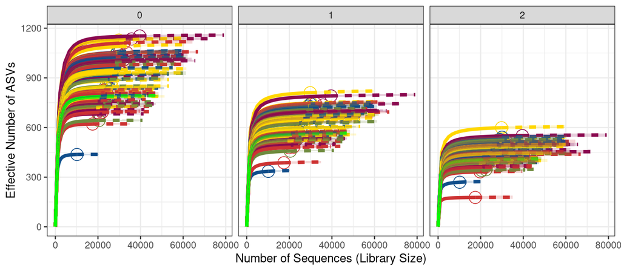

```r
# Plot rarefaction!
# rarefaction/extrapolation curve, type = 1

# Order q:
  # 0 = Richness/ Number of Total taxa
  # 1 = Exponential Shannon / Number of "Common" taxa
  # 2 = Inverse Simpson / Number of "Dominant" taxa

ggiNEXT(iNEXT_data, type = 1, facet.var = "Order.q") +
 facet_wrap(~Order.q, scales = "fixed") +
  scale_color_manual(values = iNEXT_color_df$treatment_colors, guide = FALSE) +
  scale_fill_manual(values = iNEXT_color_df$treatment_colors, guide = FALSE) +
  scale_shape_manual(values = rep(1, 60), guide = FALSE) +
  # scale_shape_manual(values = base::rep(17, nsamples(raw_preprocessed_physeq)),
  #                  guide = TRUE) +
  labs(x = "Number of Sequences (Library Size)",
       y = "Effective Number of ASVs") +
  theme_bw() +
  theme(legend.position = "none")
```

# Manually plot Diversity

## Rarefaction

```r
iNEXT_manual_df <-
  iNEXT_data$iNextEst$size_based %>%
  dplyr::rename(names = Assemblage) %>%
  # Fix the samples names
  mutate(names = gsub(names, pattern = "[.]", replace = "-"),
         names = gsub(names, pattern = "X", replace = "")) %>%
  filter(names != "SRR11364374") %>%
  # join with metadata
  left_join(., metadata_df, by = "names") %>%
  # Add colors to data frame
  left_join(., data.frame(treatment_colors = treatment_colors,
                         treatment = names(treatment_colors)),
              by = "treatment")

unique(iNEXT_manual_df$treatment)
```

```
## [1] "N180" "N120" "N360" "N240" "N0"
```

```r
iNEXT_manual_df %>%
  filter(is.na(treatment))
```

```
##  [1] names                          m
##  [3] Method                         Order.q
##  [5] qD                             qD.LCL
##  [7] qD.UCL                         SC
##  [9] SC.LCL                         SC.UCL
## [11] altitude                       Assay.Type
## [13] AvgSpotLen                     Bases
## [15] BioProject                     BioSample
## [17] BioSampleModel                 Bytes
## [19] Center.Name                    Collection_Date
## [21] Consent                        DATASTORE.filetype
## [23] DATASTORE.provider             DATASTORE.region
## [25] Experiment                     geo_loc_name_country
## [27] geo_loc_name_country_continent geo_loc_name
## [29] Id                             Instrument
## [31] isolation_source               lat_lon
## [33] Library.Name                   LibraryLayout
## [35] LibrarySelection               LibrarySource
## [37] Organism                       Platform
## [39] ReleaseDate                    create_date
## [41] version                        Sample.Name
## [43] treatment                      year
## [45] SRA.Study                      strain
## [47] input                          filtered
## [49] denoisedF                      denoisedR
## [51] merged                         nochim
## [53] perc_reads_retained            treatment_colors
## <0 rows> (or 0-length row.names)
```

```r
# Inspect
dim(iNEXT_manual_df)
```

```
## [1] 7080   54
```

```r
str(iNEXT_manual_df)
```

```
## 'data.frame':    7080 obs. of  54 variables:
##  $ names                         : chr  "SRR11364336" "SRR11364336" "SRR11364336" "SRR11364336" ...
##  $ m                             : num  1 1285 2569 3853 5137 ...
##  $ Method                        : chr  "Rarefaction" "Rarefaction" "Rarefaction" "Rarefaction" ...
##  $ Order.q                       : num  0 0 0 0 0 0 0 0 0 0 ...
##  $ qD                            : num  1 512 632 679 702 ...
##  $ qD.LCL                        : num  1 509 628 675 699 ...
##  $ qD.UCL                        : num  1 515 635 683 706 ...
##  $ SC                            : num  0.0025 0.8439 0.9461 0.9753 0.9868 ...
##  $ SC.LCL                        : num  0.00244 0.84235 0.94509 0.97453 0.98625 ...
##  $ SC.UCL                        : num  0.00255 0.84552 0.94714 0.976 0.98727 ...
##  $ altitude                      : chr  "not collected" "not collected" "not collected" "not collected" ...
##  $ Assay.Type                    : chr  "AMPLICON" "AMPLICON" "AMPLICON" "AMPLICON" ...
##  $ AvgSpotLen                    : int  602 602 602 602 602 602 602 602 602 602 ...
##  $ Bases                         : int  29559404 29559404 29559404 29559404 29559404 29559404 29559404 29559404 29559404 29559404 ...
```

[output cut: 40 more lines]

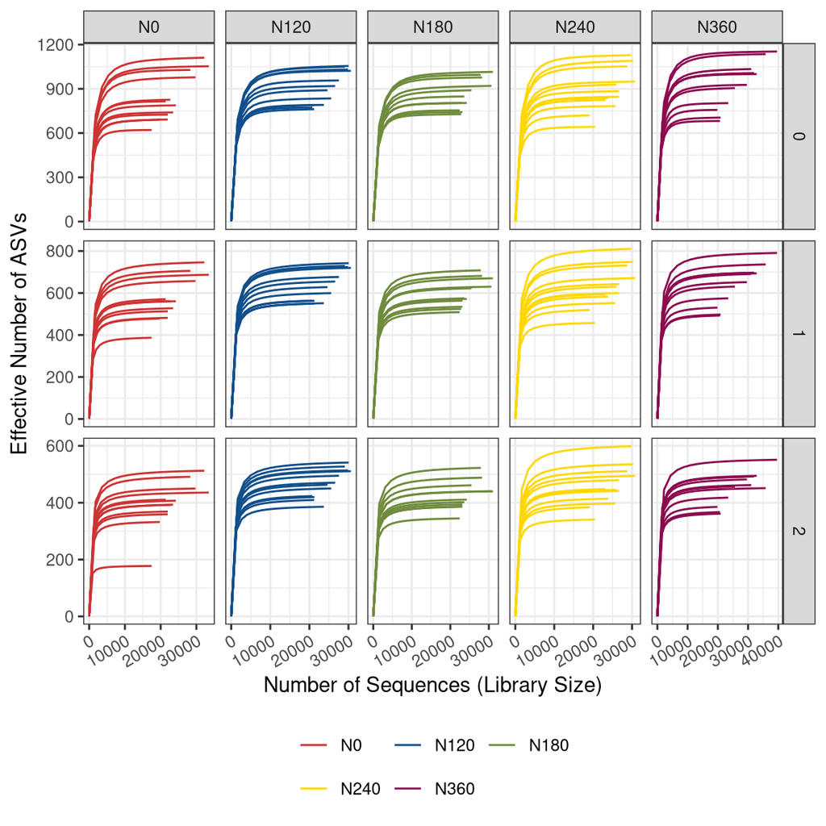

```r
# Plot it - Rarefaction Curve
iNEXT_manual_df %>%
  # Filter out rows that are calculated by rarefaction from iNEXT
  dplyr::filter(Method == "Rarefaction") %>%
  # Now, let's draw the plot, be sure to group by the samples if using geom_line!
  ggplot(aes(x = m, y= qD, color = treatment, group = names)) +
  geom_line() +
  # Facet with the treatment to see the samples better
  facet_grid(Order.q~treatment, scales = "free") +
  scale_color_manual(values = treatment_colors) +
  labs(x = "Number of Sequences (Library Size)",
       y = "Effective Number of ASVs") +
  theme_bw() +
  guides(color = guide_legend(nrow = 2, byrow = TRUE)) +
  theme(legend.position = "bottom",
        axis.text.x = element_text(angle = 30, vjust = 1, hjust = 1),
        legend.title = element_blank())
```

**Interpretation**

Order q of:

- 0 = Richness/ Number of Total taxa
- 1 = Exponential Shannon / Number of “Common” taxa
- 2 = Inverse Simpson / Number of “Dominant” taxa

From the plots above, For richness, the effective number of ASVs were in the order of N360 > N240 > N0 > N120 > N180. Effective number of ASVs changed a little bit cpmaring the treatments from Richness to Shannon to Simpson.

Richness > Shannon > Simpson

Since, this plot was plotted was manually plotted, the axes were different for each of the diversity measure and it seems that the curves plateaued as: Simpson > Shannon > Richness.

Other things that we note from these figures is that, as q increases from 0 to 1 to 2, the abundance of the species is weighted more, so the rarefaction curve plateaus earlier. Most of the sample rarefaction curves appear to plateau but we need to look deeper.